# Exploration of all buildings in the Netherlands

## Preliminary Wrangling

> This dataset does preliminary explore a dataset of rented buildings in the Netherlands. The data and outcomes of this notebook are confidential should not be shared.

```python
# import all packages and set plots to be embedded inline
import numpy as np
import pandas as pd
import matplotlib.pyplot as plt
import seaborn as sns
from pathlib import Path

%matplotlib inline

# pd.set_option('max_rows',100)
pd.set_option('min_rows',20)

pd.set_option('max_columns',100)

df_raw = pd.read_csv(
    r'D:\OneDrive - MVGM\WerkbestandenYannick\Werkmap_Python\Projecten\wh\data\batch_huur_20210623\input\factiararems-23-06-21.csv'
, dtype={'SoortGarage':str, 'Land':str, 'HuurprijsConditie':str, 'HuurprijsSpecificatie':str,
       'KadastraalEigendom':str, 'KadastraalOmvang':str, 'MakelaarNaam':str, 'STATUS':str,
       'StatusVerhuurd':str})

df_raw = df_raw[['Bron', 'Bouwjaar', 'EnergieLabel', 'GebruiksOppervlakte', 'AanmeldDatum', 'Postcode',
       'TypeWoning', 'Looptijd', 'Ingetrokken', 'TransactieHuurPrijs',
       'SoortAppartement',
       'TransactieDatumOndertekeningAkte', 'OnderhoudsNiveauBinnen', 'OnderhoudsNiveauBuiten',
       'GemeenteNaam','HuurprijsConditie']]

df = df_raw.copy(deep=True)

# Read the data
df = df_raw.copy(deep=True)

# Some data wrangling such that the data can be used for visualisation

# Energielabels / energylabels
df.EnergieLabel = df.EnergieLabel.fillna('C') # Median
df.EnergieLabel = df.EnergieLabel.replace({"A+++++":"A", "A++++":"A", "A+++":"A", "A++":"A", "A+":"A"})

# column formatting
df.OnderhoudsNiveauBinnen = df.OnderhoudsNiveauBinnen.str.capitalize()
df.OnderhoudsNiveauBuiten = df.OnderhoudsNiveauBuiten.str.capitalize()
df.GebruiksOppervlakte = df.GebruiksOppervlakte.round(0)
df.AanmeldDatum = pd.to_datetime(df.AanmeldDatum)
df.TransactieDatumOndertekeningAkte = pd.to_datetime(df.TransactieDatumOndertekeningAkte)
df.TypeWoning = df.TypeWoning.where(df.TypeWoning.notna(), df.SoortAppartement)
df.TypeWoning = df.TypeWoning.str.capitalize()

# Since there are too many municipalities. They are classified in the 4 biggest municipalities, the 5th until the 45th biggest municipalities and the rest.
# This is an usual classification for classifications in the Neterlands
G4 = ['Amsterdam','Utrecht','Rotterdam',"'s-Gravenhage"]
G40 = ['Alkmaar', 'Almelo', 'Almere', 'Alphen aan den Rijn', 'Amersfoort', 'Apeldoorn', 'Arnhem', 'Assen', 'Breda', 'Delft', 'Deventer', 'Dordrecht', 'Ede', 'Eindhoven', 'Emmen', 'Enschede', 'Gouda', 'Groningen', 'Haarlem', 'Haarlemmermeer', 'Heerlen', 'Helmond', 'Hengelo', "'s-Hertogenbosch", 'Hilversum', 'Hoorn', 'Leeuwarden', 'Leiden', 'Lelystad', 'Maastricht', 'Nijmegen', 'Oss', 'Roosendaal', 'Sittard-Geleen', 'Schiedam', 'Tilburg', 'Venlo', 'Zaanstad', 'Zoetermeer','Zwolle']
df['GemeenteCat'] = df.GemeenteNaam.where(~df.GemeenteNaam.isin(G4), 'G4').where(~df.GemeenteNaam.isin(G40), 'G40').where(df.GemeenteNaam.isin(G4+G40), 'Overig')

#Categorical values
# Sorted from less good to 'better'
ordinal_var_dict = {'EnergieLabel': ['G','F','E','D','C', 'B', 'A'],
                    'OnderhoudsNiveauBinnen': ['Slecht', 'Slecht tot matig', 'Matig', 'Matig tot redelijk'
                                               , 'Redelijk', 'Redelijk tot goed', 'Goed', 'Goed tot uitstekend', 'Uitstekend'],
                    'OnderhoudsNiveauBuiten': ['Slecht', 'Slecht tot matig', 'Matig', 'Matig tot redelijk'
                                               , 'Redelijk', 'Redelijk tot goed', 'Goed', 'Goed tot uitstekend', 'Uitstekend'],
                    'GemeenteCat': ['G4', 'G40', 'Overig'],
                   }
for var in ordinal_var_dict:
    ordered_var = pd.api.types.CategoricalDtype(ordered = True,categories = ordinal_var_dict[var])
    df[var] = df[var].astype(ordered_var)

df.TypeWoning.where(df.TypeWoning.notna(), 'Onbekend', inplace=True)
for i in range(1,9):
    df.TypeWoning.where(~df.TypeWoning.str.contains(f'{i}-k flat'), f'{i}-k flatwoning', inplace=True)
df.TypeWoning.where(~df.TypeWoning.str.contains('Flat'), 'Flatwoning', inplace=True)

# Only include the 16 most used WoningTypes. All types with more than 10k entries
l = df.TypeWoning.value_counts(dropna=False).index[:16]
df = df[df.TypeWoning.isin(l)]

# Only look at transactions which are really made.
df = df[df.Ingetrokken==0]
df.drop(columns=['SoortAppartement','Ingetrokken'], inplace=True)

df.TransactieHuurPrijs.where((df.HuurprijsConditie=='per maand') | (df.HuurprijsConditie.isnull()), df.TransactieHuurPrijs/12, inplace=True)
df.drop(columns='HuurprijsConditie', inplace=True)

df.where((df.GebruiksOppervlakte > 5) & (df.GebruiksOppervlakte < 700), inplace=True)

# Cap the renting prices. From my work I know that the prices generally do not exceed 2500 but there are existing outliers of habitats with outliers around 6k per month
df = df[df.TransactieHuurPrijs < 6_500]

df.GebruiksOppervlakte.fillna(1, inplace=True)

df.GebruiksOppervlakte = df.GebruiksOppervlakte.astype(int)

df.insert(2, 'M2HuurPrijs', df.TransactieHuurPrijs / df.GebruiksOppervlakte)

df.Bouwjaar = df.Bouwjaar.where(df.Bouwjaar<=2021).where(df.Bouwjaar>1500)
```

```python
df.columns
```

```
Index(['Bron', 'Bouwjaar', 'M2HuurPrijs', 'EnergieLabel',
       'GebruiksOppervlakte', 'AanmeldDatum', 'Postcode', 'TypeWoning',
       'Looptijd', 'TransactieHuurPrijs', 'TransactieDatumOndertekeningAkte',
       'OnderhoudsNiveauBinnen', 'OnderhoudsNiveauBuiten', 'GemeenteNaam',
       'GemeenteCat'],
      dtype='object')
```

### What is the structure of your dataset?

```python
print(df.shape)
print(df.dtypes)
display(df.head(8))
```

```
(534085, 15)
Bron                                        object
Bouwjaar                                   float64
M2HuurPrijs                                float64
EnergieLabel                              category
GebruiksOppervlakte                          int32
AanmeldDatum                        datetime64[ns]
Postcode                                    object
TypeWoning                                  object
Looptijd                                   float64
TransactieHuurPrijs                        float64
TransactieDatumOndertekeningAkte    datetime64[ns]
OnderhoudsNiveauBinnen                    category
OnderhoudsNiveauBuiten                    category
GemeenteNaam                                object
GemeenteCat                               category
dtype: object
```

|  | Bron | Bouwjaar | M2HuurPrijs | EnergieLabel | GebruiksOppervlakte | AanmeldDatum | Postcode | TypeWoning | Looptijd | TransactieHuurPrijs | TransactieDatumOndertekeningAkte | OnderhoudsNiveauBinnen | OnderhoudsNiveauBuiten | GemeenteNaam | GemeenteCat |
| --- | --- | --- | --- | --- | --- | --- | --- | --- | --- | --- | --- | --- | --- | --- | --- |
| 0 | TIARA | 1997.0 | 8.500000 | B | 150 | 2006-01-10 | 2851CH | 2-onder-1-kapwoning | 23.0 | 1275.0 | 2006-02-02 | Goed | Goed | Krimpenerwaard | Overig |
| 1 | TIARA | 1937.0 | 7.307692 | C | 130 | 2006-01-02 | 2025RB | Tussenwoning | 25.0 | 950.0 | 2006-01-27 | Goed | Goed | Haarlem | G40 |
| 3 | TIARA | 1785.0 | 10.583333 | C | 60 | 2006-01-10 | 2312XV | Bovenwoning | 163.0 | 635.0 | 2006-06-22 | Goed | Goed | Leiden | G40 |
| 4 | TIARA | 1937.0 | 7.727273 | D | 110 | 2006-01-10 | 9722GP | Bovenwoning | 133.0 | 850.0 | 2006-05-23 | Goed | Goed | Groningen | G40 |
| 5 | TIARA | 2004.0 | 6.168831 | B | 154 | 2006-01-12 | 2152EX | Hoekwoning | 53.0 | 950.0 | 2006-03-06 | Uitstekend | Uitstekend | Haarlemmermeer | G40 |
| 7 | TIARA | 1970.0 | 6.818182 | C | 110 | 2006-01-05 | 4538AM | 2-onder-1-kapwoning | 749.0 | 750.0 | 2008-01-24 | Goed | Goed | Terneuzen | Overig |
| 8 | TIARA | 1970.0 | 5.576923 | D | 130 | 2006-01-05 | 7741GT | Bovenwoning | 68.0 | 725.0 | 2006-03-14 | Goed | Goed | Coevorden | Overig |
| 9 | TIARA | 1900.0 | 7.160000 | G | 125 | 2006-01-13 | 2805AG | Hoekwoning | 33.0 | 895.0 | 2006-02-15 | Goed | Goed | Gouda | G40 |

There are 15 features in the dataset:

Bron is the source from which the data is coming.

Bouwjaar is the year in which the building is build.

M2HuurPrijs is the square metre price for renting.

GebruiksOppervlakte is the usable square metres in a house.

AanmeldDatum is the date at which the building is put online.

Postcode is zipcode/postalcode.

TypeWoning is the type of house people live in.

Looptijd is the time between putting the house online and the signing of the contract.

TransactieHuurPrijs is the total amount of euros paid.

TransactieDatumOndertekeningAkte is the date that the contract is signed.

OnderhoudsNiveaBinnen is the maintenance level inside of the building.

OnderhoudsNiveaBuiten is the maintenance level outside of the building.

GemeenteNaam is the name of the municipality.

GemeenteCat is the category of municipality. The big four, number 5 until 45 and the rest.

OnderhoudsNiveauBinnen, OnderhoudsNiveauBuiten and Energielabels are ordinal features. They are sorted from 'bad' to 'better'. In the case of GemeenteCat (Municipality Category) it is sorted from bigger municipality category to smaller. 'EnergieLabel': ['G','F','E','D','C', 'B', 'A'] 'OnderhoudsNiveauBinnen': ['Slecht', 'Slecht tot matig', 'Matig', 'Matig tot redelijk', 'Redelijk', 'Redelijk tot goed', 'Goed', 'Goed tot uitstekend', 'Uitstekend'] 'OnderhoudsNiveauBuiten': ['Slecht', 'Slecht tot matig', 'Matig', 'Matig tot redelijk', 'Redelijk', 'Redelijk tot goed', 'Goed', 'Goed tot uitstekend', 'Uitstekend'] 'GemeenteCat': ['G4', 'G40', 'Overig']

### What is/are the main feature(s) of interest in your dataset?

> The main feature of interest is 'M2HuurPrijs', else 'TransactieHuurPrijs'. Translated this means rental price which is actually being paid.

### What features in the dataset do you think will help support your investigation into your feature(s) of interest?

> The assumption is that Gebruiksoppervlakte (square metres), WijkNaam (districtname) and TypeWoning (House type) have 'relatively much' influence. The following features also have some influence but less EnergieLabel (EnergyLabel), SoortObject, OnderhoudsNiveauBinnen (maintenance level inside) and OnderhoudsNiveauBuiten (maintenance level outside).

It is hard to find enough datapoints in the WijkNaam column. Therefore, the main focus of the Univariate Exploration will be TypeWoning, EnergieLabel and GebruiksOppervlakte.

## Univariate Exploration

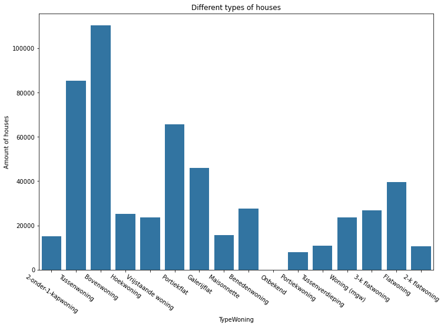

```python
base_color = sns.color_palette()[0]
plt.figure(figsize=[12, 8])
sns.countplot(data=df, x='TypeWoning', color=base_color)
plt.xticks(rotation=-35);
plt.ylabel("Amount of houses")
plt.title('Different types of houses');
```

```python
df.EnergieLabel.value_counts(dropna=False)
```

```
C    249838
A    121523
B     58778
D     42996
E     29412
F     17224
G     14314
Name: EnergieLabel, dtype: int64
```

Better energylabels are more common. Recall that A is best and G is worst.

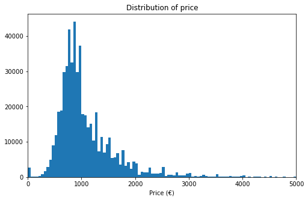

```python
# start with a standard-scaled plot
binsize = 50
bins = np.arange(0, df.TransactieHuurPrijs.max()+binsize, binsize)

plt.figure(figsize=[8, 5])
plt.hist(data = df, x = 'TransactieHuurPrijs', bins = bins)
plt.xlabel('Price (€)')
plt.title('Distribution of price')
plt.xlim(0,5000)
plt.show()
```

Long tail on the price distribution. Maybe the square metre price can give us more information

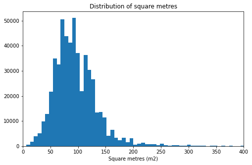

```python
# start with a standard-scaled plot
binsize = 200
bins = np.arange(0, df.GebruiksOppervlakte.max(), binsize)

plt.figure(figsize=[8, 5])
plt.hist(data = df, x = 'GebruiksOppervlakte', bins = 100)
plt.title('Distribution of square metres')
plt.xlim(0,400)
plt.xlabel('Square metres (m2)')
plt.show()
```

Almost all houses are between 30 and 150 square meters. Long tail which are probably some outliers.

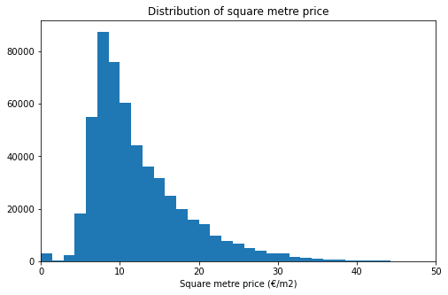

```python
# start with a standard-scaled plot
binsize = 200
bins = np.arange(0, df.GebruiksOppervlakte.max()+binsize, binsize)

plt.figure(figsize=[8, 5])
plt.title('Distribution of square metre price')
plt.hist(data = df, x = 'M2HuurPrijs', bins = 200)
plt.xlabel('Square metre price (€/m2)')
plt.xlim(0, 50)
plt.show()
```

Really long tail. Try this with a logscale.

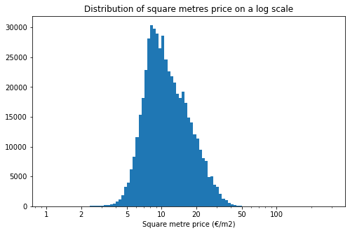

```python
# start with a standard-scaled plot
log_binsize = 0.025
bins = 10 ** np.arange(0, np.log10(df['M2HuurPrijs'].max())+log_binsize, log_binsize)


plt.figure(figsize=[8, 5])
plt.hist(data = df, x = 'M2HuurPrijs', bins = bins)
plt.xscale('log')
plt.xticks([1, 2, 5, 10, 20, 50, 100], [1, 2, 5, 10, 20, 50, 100]) #[0, 5, 10, 15, 20, 25, 30, 35, 40])
plt.xlabel('Square metre price (€/m2)')
plt.title("Distribution of square metres price on a log scale")
plt.show()
```

Plotting the square metre price on a logarithmic scale takes on an unimodal distribution.

```python
df.GemeenteCat.value_counts()
```

```
Overig    194919
G4        170945
G40       168221
Name: GemeenteCat, dtype: int64
```

This shows that there are roughly an equal amount of rental transactions in the G4, G40 and the rest.

### Discuss the distribution(s) of your variable(s) of interest. Were there any unusual points? Did you need to perform any transformations?

> There is a log transformation on the M2HuurPrijs column.

### Of the features you investigated, were there any unusual distributions? Did you perform any operations on the data to tidy, adjust, or change the form of the data? If so, why did you do this?

> Since it was my own dataset. All the operations are performed in the beginning.

## Bivariate Exploration

> In this section, investigate relationships between pairs of variables in your data. Make sure the variables that you cover here have been introduced in some fashion in the previous section (univariate exploration).

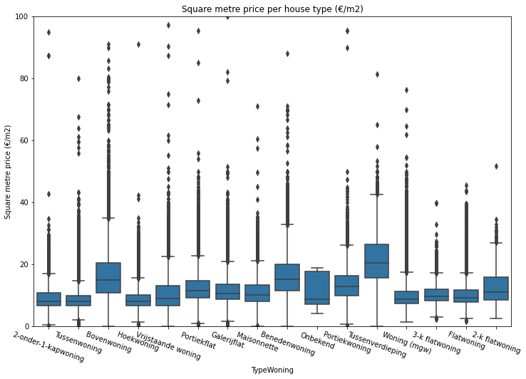

```python
plt.figure(figsize=[12,8])
sns.boxplot(data=df, y='M2HuurPrijs', x='TypeWoning', color=base_color)
plt.title('Square metre price per house type (€/m2)')
plt.ylabel('Square metre price (€/m2)')
plt.ylim(0,100)
plt.xticks(rotation=-20);
```

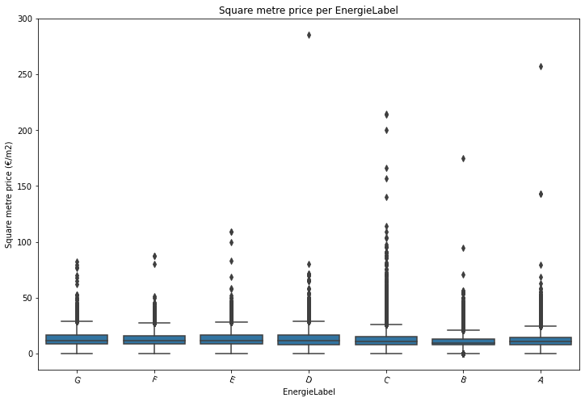

```python
plt.figure(figsize=[12,8])
sns.boxplot(data=df, y='M2HuurPrijs', x='EnergieLabel', color=base_color)
plt.title('Square metre price per EnergieLabel')
plt.ylabel('Square metre price (€/m2)')
plt.xticks(rotation=-20);
```

Not a lot of difference is visible. Maybe this is clearer when M2HuurPrijs is capped.

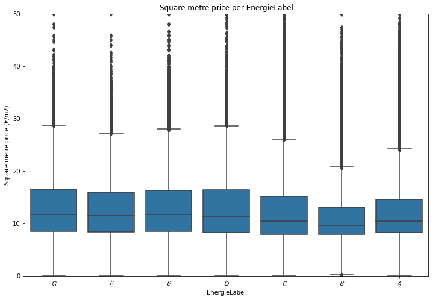

```python
plt.figure(figsize=[12,8])
sns.boxplot(data=df, y='M2HuurPrijs', x='EnergieLabel', color=base_color)
plt.title('Square metre price per EnergieLabel')
plt.ylim(0,50)
plt.ylabel('Square metre price (€/m2)')
plt.xticks(rotation=-20);
```

Closer investigation shows that the M2HuurPrijs (recall that this is square metre price) also shows no difference.

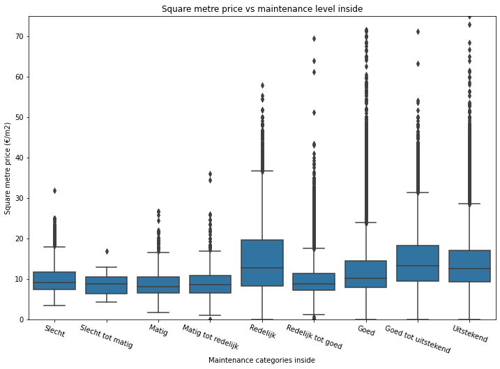

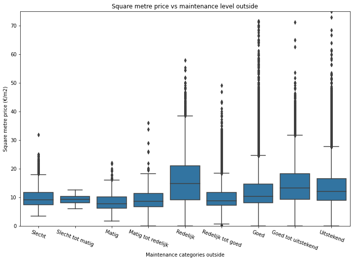

```python
plt.figure(figsize=[12,8])
sns.boxplot(data=df, y='M2HuurPrijs', x='OnderhoudsNiveauBinnen', color=base_color)
plt.title('Square metre price vs maintenance level inside')
plt.ylim(0, 75)
plt.ylabel('Square metre price (€/m2)')
plt.xlabel('Maintenance categories inside')
plt.xticks(rotation=-20);
plt.show()

plt.figure(figsize=[12,8])
sns.boxplot(data=df, y='M2HuurPrijs', x='OnderhoudsNiveauBuiten', color=base_color)
plt.title('Square metre price vs maintenance level outside')
plt.ylim(0, 75)
plt.ylabel('Square metre price (€/m2)')
plt.xlabel('Maintenance categories outside')
plt.xticks(rotation=-20);
plt.show()
```

Maintenance levels inside and outside show the same trend. Therefore, I won't make any difference in this in further exploration.

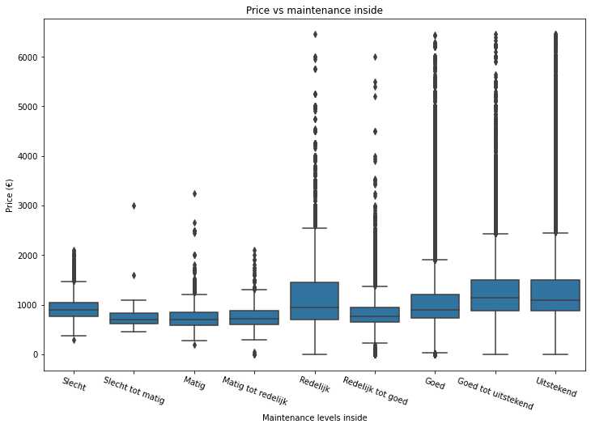

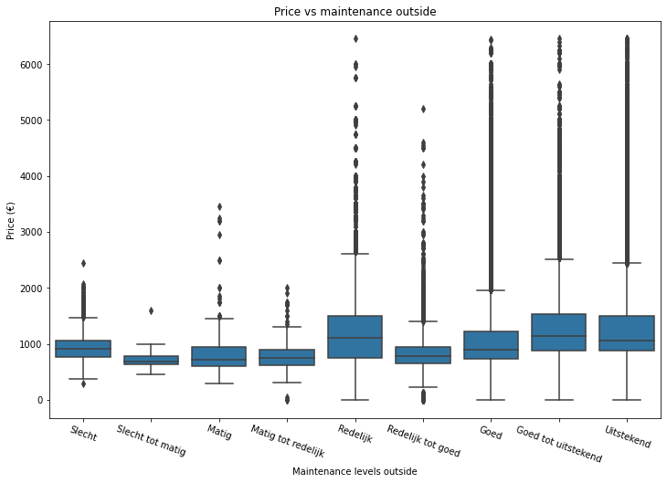

```python
plt.figure(figsize=[12,8])
sns.boxplot(data=df, y='TransactieHuurPrijs', x='OnderhoudsNiveauBinnen', color=base_color)
plt.title('Price vs maintenance inside')
# plt.ylim(0, 75)
plt.ylabel('Price (€)')
plt.xlabel('Maintenance levels inside')
plt.xticks(rotation=-20);
plt.show()

plt.figure(figsize=[12,8])
sns.boxplot(data=df, y='TransactieHuurPrijs', x='OnderhoudsNiveauBuiten', color=base_color)
plt.title('Price vs maintenance outside')
# plt.ylim(0, 75)
plt.ylabel('Price (€)')
plt.xlabel('Maintenance levels outside')
plt.xticks(rotation=-20);
plt.show()
```

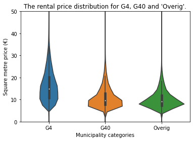

```python
sns.violinplot(data=df, y='M2HuurPrijs', x='GemeenteCat');
plt.ylim(0, 50)
plt.ylabel("Square metre price (€)")
plt.xlabel("Municipality categories")
plt.title("The rental price distribution for G4, G40 and 'Overig'.");
```

The distributions of G40 and Overig are somewhat comparable. However, G4 has a completely different shape. The shape is longer which means that there is more variation of the square metre prices in the G4. Whereas a mean is more obvious in the other two categories.

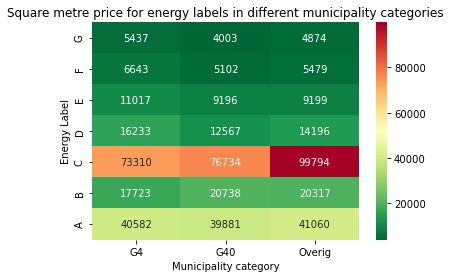

```python
heat_df = df.groupby(['GemeenteCat','EnergieLabel']).count()['M2HuurPrijs'].unstack('GemeenteCat')
sns.heatmap(heat_df, cmap='RdYlGn_r', annot=True, fmt='g');
plt.title('Square metre price for energy labels in different municipality categories');
plt.xlabel("Municipality category")
plt.ylabel("Energy Label");
```

There are no significant observations from this plot. It seems that the different municipality categories don't matter a lot when considering Energy Labels.

### Talk about some of the relationships you observed in this part of the investigation. How did the feature(s) of interest vary with other features in the dataset?

> Maintenance inside and outside have no significant different effect. Plotting for maintenance vs price/price per square metre seems to show the same trend. Which is slightly increasing for better maintenance features. I did not expect G40 and "Overig" to follow somewhat the same distribution against square metre price.

### Did you observe any interesting relationships between the other features (not the main feature(s) of interest)?

> Municipality category doesn't indicate anything regarding Energy Labels.

## Multivariate Exploration

> Create plots of three or more variables to investigate your data even further. Make sure that your investigations are justified, and follow from your work in the previous sections.

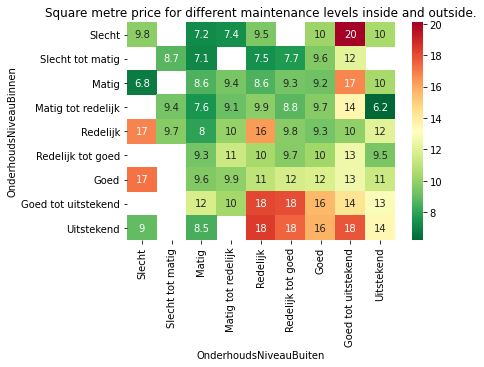

```python
heat_df = df.groupby(['OnderhoudsNiveauBinnen','OnderhoudsNiveauBuiten']).mean()['M2HuurPrijs'].unstack()
sns.heatmap(heat_df, cmap='RdYlGn_r', annot=True);
plt.title('Square metre price for different maintenance levels inside and outside.');
```

Since the data is more granular. Check if there are still enough data points in every category.

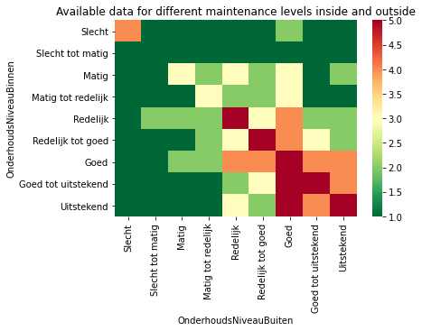

```python
x = df.groupby(['OnderhoudsNiveauBinnen','OnderhoudsNiveauBuiten']).count()['M2HuurPrijs'].unstack()
x2 = x.where(x>300_000,5).where(x>5000,4).where(x>1000,3).where(x>100,2).where(x>10,1)
sns.heatmap(x2, cmap='RdYlGn_r');
plt.title('Available data for different maintenance levels inside and outside');#, cbar_kws=cbar_vals)
```

Less than 10 data points is not sufficient (dark green), between 10 and 100 data points is low reliability (light green). More than 100 data points is seen as sufficient to make assumptions. It is evident that maintenance level outside has to be atleast 'Matig tot redelijk' and maintenance level inside has to be atleast 'matig'.

Conclusions can not be drawn if maintenance levels inside as well as outside are 'Slecht' or 'Slecht tot matig'. (The worst two categories).

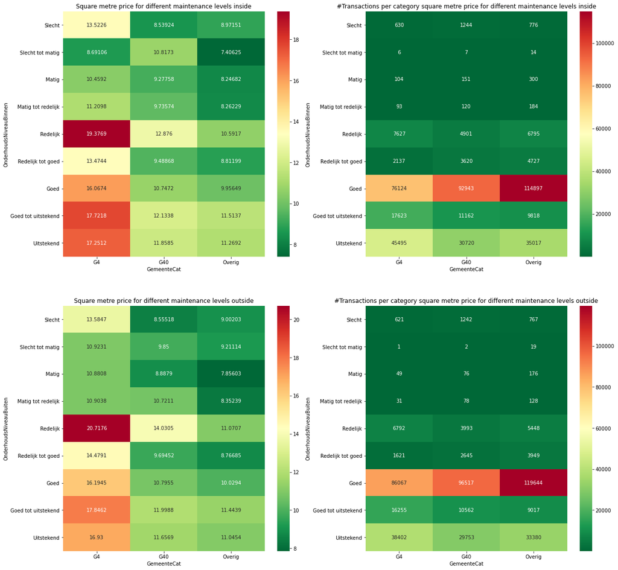

```python
fig = plt.figure(figsize=(20,20))
ax1 = fig.add_subplot(221)
ax2 = fig.add_subplot(222)
ax3 = fig.add_subplot(223)
ax4 = fig.add_subplot(224)

plt.title("Square metre prices for different maintenance levels inside and outside.")

ax1.set_title('Square metre price for different maintenance levels inside');
heat_df = df.groupby(['OnderhoudsNiveauBinnen','GemeenteCat']).mean()['M2HuurPrijs'].unstack()
sns.heatmap(heat_df, cmap='RdYlGn_r', annot=True, fmt='g', ax=ax1);

ax2.set_title('#Transactions per category square metre price for different maintenance levels inside');
heat_df = df.groupby(['OnderhoudsNiveauBinnen','GemeenteCat']).count()['M2HuurPrijs'].unstack()
sns.heatmap(heat_df, cmap='RdYlGn_r', annot=True, fmt='g', ax=ax2);

ax3.set_title('Square metre price for different maintenance levels outside');
heat_df = df.groupby(['OnderhoudsNiveauBuiten','GemeenteCat']).mean()['M2HuurPrijs'].unstack()
sns.heatmap(heat_df, cmap='RdYlGn_r', annot=True, fmt='g', ax=ax3);

ax4.set_title('#Transactions per category square metre price for different maintenance levels outside');
heat_df = df.groupby(['OnderhoudsNiveauBuiten','GemeenteCat']).count()['M2HuurPrijs'].unstack()
sns.heatmap(heat_df, cmap='RdYlGn_r', annot=True, fmt='g', ax=ax4);
```

Investigating different municipality categories shows that maintenance levels can not be simply put together. G4 (the biggest 4 municipalities) have as expected the highest renting prices per square metre. 'Overig' (municipality 45 until 355 in order of magnitude) have the lowest renting prices.

For some reason 'Redelijk' (average) is a square metre price outlier, inside and outside. As is visible in the right heatmaps, this is not due to not sufficient data. The exact problem is most likely due to the 'standard' values of the form which is being filled in when a transaction is made. A domain expert is needed to explain this.

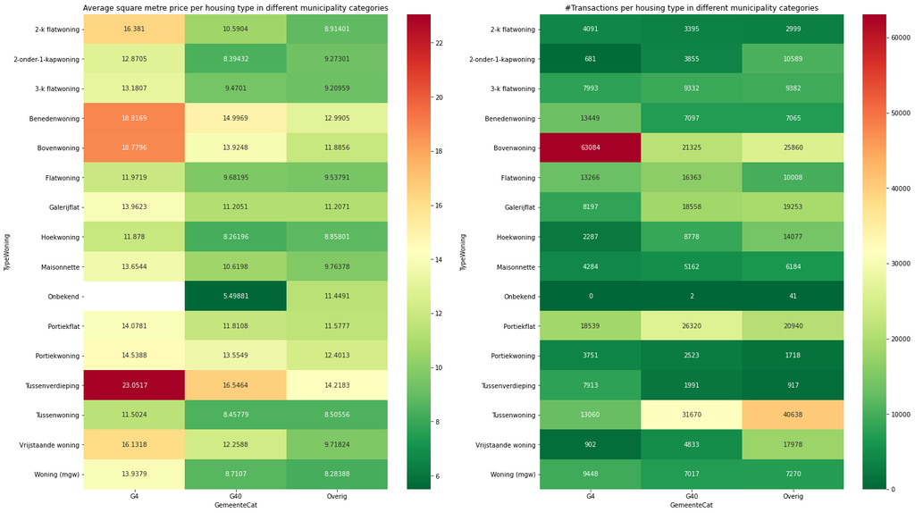

```python
fig = plt.figure(figsize=(24,14))
ax1 = fig.add_subplot(121)
ax2 = fig.add_subplot(122)

ax1.set_title("Average square metre price per housing type in different municipality categories")
heat_df = df.groupby(['TypeWoning','GemeenteCat']).mean()['M2HuurPrijs'].unstack()
sns.heatmap(heat_df, cmap='RdYlGn_r', annot=True, fmt='g', ax=ax1);

ax2.set_title("#Transactions per housing type in different municipality categories")
heat_df = df.groupby(['TypeWoning','GemeenteCat']).count()['M2HuurPrijs'].unstack()
sns.heatmap(heat_df, cmap='RdYlGn_r', annot=True, fmt='g', ax=ax2);
```

Even though 'Vrijstaande woning' is one of the most luxurious ones. 'Benedenwoning', 'Bovenwoning' and 'Tussenverdieping' are appartment types and are more common in the city centre. Therefore, it could be more expensive. However, this is just an assumption.

### Talk about some of the relationships you observed in this part of the investigation. Were there features that strengthened each other in terms of looking at your feature(s) of interest?

> Maintenance levels inside as well as outside strengthened each other. A 'better' municipality categorie also strenghtened the square metre price on top off that.

### Were there any interesting or surprising interactions between features?

> It was surprising that the most expensive house types were 'Benedenwoning', 'Bovenwoning' and 'Tussenverdieping'. Which means lower, middel and upper floor. Not 'vrijstaande woning' which is the most luxurious type of housing.

> Maintenance level inside/outside 'mediocre' has a higher square metre price than 'mediocre/good', 'good', 'good/fantastic' and 'fantastic'. This is really contraintuitive and a domain expert indicated that 'mediocre' is the standard value for this field. Thus my assumption is that that could be the cause of the outlier.